# R Notebook

# Titanic Dataset - Kaggle

Refazendo os passos do excelente relatório de Megan Risdal https://www.kaggle.com/mrisdal/titanic/exploring-survival-on-the-titanic

```r
library('randomForest')
```

Carregar os dados de treinamento e testes, e juntar em uma variável full

```r
library('scales')
```

Agora, analisando o nome, extrair o título (Mr, Mrs, Master, Miss)

```r
table(full$Sex, full$Title)
```

```
         Capt Col Don Dona  Dr Jonkheer Lady Major Master Miss  Mr Mrs Rev Sir the Countess
  female    0   0   0    1   1        0    1     0      0  264   0 198   0   0            1
  male      1   4   1    0   7        1    0     2     61    0 757   0   8   1            0
```

Títulos com poucas pessoas são raros, então juntar sobre um novo nome “Rare Title”:

```r
rare_title <- c('Dona', 'Lady', 'the Countess','Capt', 'Col', 'Don',
                'Dr', 'Major', 'Rev', 'Sir', 'Jonkheer')
full$Title[full$Title %in% rare_title]  <- 'Rare Title'
table(full$Sex, full$Title)
```

```
         Master Miss  Mr Mrs Rare Title
  female      0  264   0 198          4
  male       61    0 757   0         25
```

Extraindo o sobre nome dos passageiros:

```r
sapply(full$Name, function(x) strsplit(x, split = '[,.]')[[1]][1])
```

[output not shown]

[output cut: 1946 more lines]

[output not shown]

Agora tentar agrupar os passageiros em família. Para fazer isso, criar uma nova variavel *family size* (Fsize), que vai ser os irmãos/esposas (siblings), e parentes/filhos (parch)

```r
paste(full$Surname, full$Fsize, sep='_')
```

[output not shown]

[output cut: 236 more lines]

Agora vamos ver como que o tamanho da familia afeta se o passageiro sa salvou ou não.

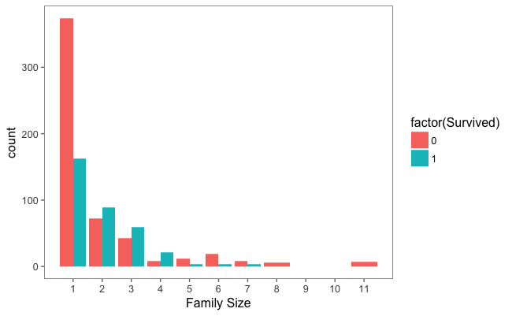

O resultado dessa análise diz que, se voce estava sozinho, a chance de sobreviver foi baixa. Se voce estava com um acompanhante (com no máximo 2 filhos ou sem filhos), tinha mais de 50% de chance de sobreviver, mais que dois filhos, a chance de sobreviver já se torna baixa novamente.

Com isso, vamos estipular o tamanho da familia em solteiros, pequena familia (ate 3 filhos) e grande familia (mais que 3 filhos).

O gráfico abaixo vai mostrar as chances de sobrevivência para cada tamanho de família:

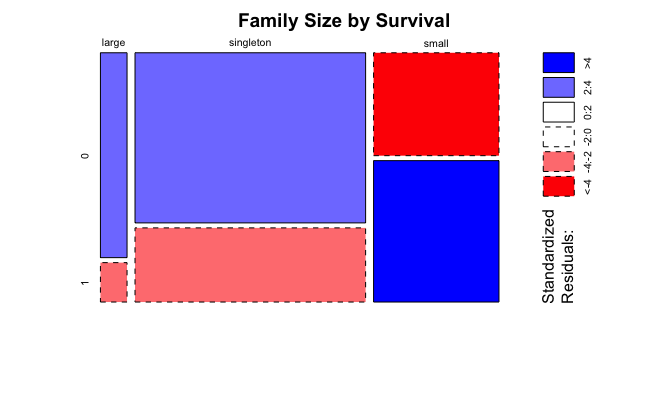

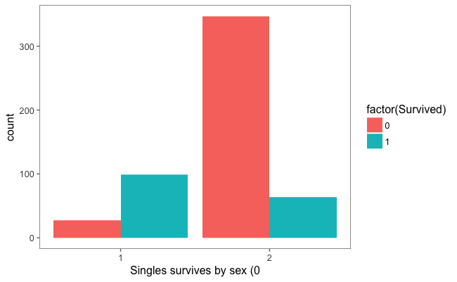

Pelo resultado dessa análise, se voce era um home solteiro no Titanic, sua chance de morrer foi grande!

## Tratando alguns dados que estão faltando

Alguns dados estão faltando, é o caso do embarque para os passageiros 62 e 830. Mas o interessante, é que temos a informação de quanto eles pagaram para entrar. Com isso, podemos inferir qual a categoria de embarque desses passageiros.

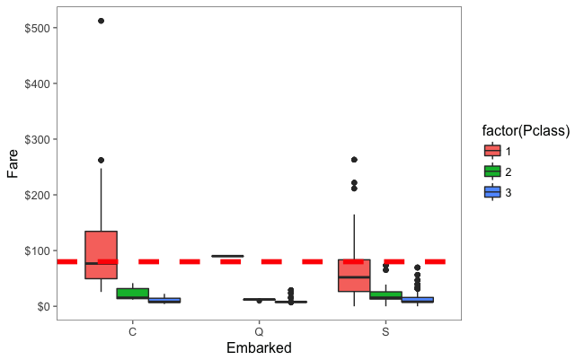

Podemos ver que as classes C e S atendem a taxa de $80, mas é bem mais provavel que a classe C seja a classe de Embarque desses passageiros:

Agora o passageiro 1044 não tem o valor pago:

|  | PassengerId | Survived | Pclass | Name | Sex | Age | SibSp | Parch | Ticket | Fare | Cabin | Embarked | Title | Surname | Fsize | Family | FsizeD |
| --- | --- | --- | --- | --- | --- | --- | --- | --- | --- | --- | --- | --- | --- | --- | --- | --- | --- |
| 1044 | 1044 | NA | 3 | Storey, Mr. Thomas | male | 60.5 | 0 | 0 | 3701 | NA |  | S | Mr | Storey | 1 | Storey_1 | singleton |

Ele é um passageiro da 3a classe (Pclass), solteiro (diferentemente do relatório inicial 495 contra 324) e embarcou em Southampton (Embarked = ‘S’). Vamos procurar passageiros desse lugar e ver qual é o comporatamento das taxas pagas por eles:

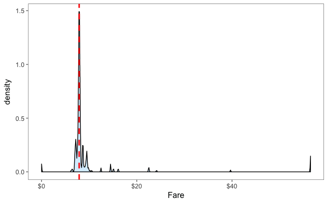

O resultado é que, em média, o valor pago para esse perfil foi por volta de $7.90, então é bem razoável dar esse valor para esse passageiro.

```r
median(class3s$Fare, na.rm = TRUE)
```

```
[1] 7.8958
```

### Idade

Uma coluna que tem bastante dado faltando é a coluna idade.

```r
sum(is.na(full$Age))
```

```
[1] 263
```

Temos 263 dados faltando. Usando a biblioteca `mice`, vamos tentar inferir esses dados faltando.

| Pclass | Sex | Age | SibSp | Parch | Fare | Embarked | Title | Fsize | FsizeD |
| --- | --- | --- | --- | --- | --- | --- | --- | --- | --- |
| 3 | male | 22.00 | 1 | 0 | 7.2500 | S | Mr | 2 | small |
| 1 | female | 38.00 | 1 | 0 | 71.2833 | C | Mrs | 2 | small |
| 3 | female | 26.00 | 0 | 0 | 7.9250 | S | Miss | 1 | singleton |
| 1 | female | 35.00 | 1 | 0 | 53.1000 | S | Mrs | 2 | small |
| 3 | male | 35.00 | 0 | 0 | 8.0500 | S | Mr | 1 | singleton |
| 3 | male | 40.00 | 0 | 0 | 8.4583 | Q | Mr | 1 | singleton |
| 1 | male | 54.00 | 0 | 0 | 51.8625 | S | Mr | 1 | singleton |
| 3 | male | 2.00 | 3 | 1 | 21.0750 | S | Master | 5 | large |
| 3 | female | 27.00 | 0 | 2 | 11.1333 | S | Mrs | 3 | small |
| 2 | female | 14.00 | 1 | 0 | 30.0708 | C | Mrs | 2 | small |

[output cut: 990 more lines]

Agora vamos comparar o resultado dos dados gerados pelo método mice com os dados que já havia antes:

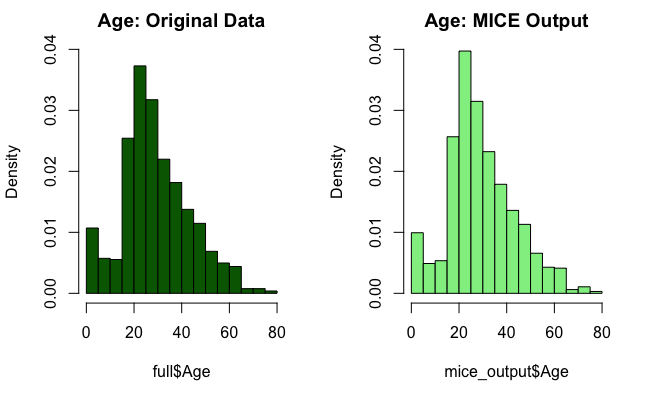

A distribuição parece bem feita, então vamos assumir os dados gerados como verdadeiros

```r
sum(is.na(full$Age))
```

```
[1] 0
```

### Maes e filhos

Proxima etapa é tentar encontrar quem são mães e filhos. Para isso, foi considerado que todos menores de 18 anos são filhos e as mães são passageiros que 1) são mulheres, 2) acima de 18 anos, 3) tem filhos e 4) não tem o título de ‘Miss’.

```r
table(full$Mother, full$Survived)
```

```
               0   1
  Mother      16  39
  Not Mother 533 303
```

Vamos ver agora como está o pattern do nosso datast:

```r
md.pattern(full)
```

[output not shown]

```
    PassengerId Pclass Sex Age SibSp Parch Fare Embarked Title Surname Fsize Family FsizeD Child Mother Ticket Survived Name
661           1      1   1   1     1     1    1        1     1       1     1      1      1     1      1      1        1    0
296           1      1   1   1     1     1    1        1     1       1     1      1      1     1      1      1        0    0
230           1      1   1   1     1     1    1        1     1       1     1      1      1     1      1      0        1    0
122           1      1   1   1     1     1    1        1     1       1     1      1      1     1      1      0        0    0
              0      0   0   0     0     0    0        0     0       0     0      0      0     0      0    352      418 1309
    Cabin
661     0    2
296     0    3
230     0    3
122     0    4
     1309 3388
```

## Predição

Agora vamos para a predição. O primeiro passo agora é atualizar as variaveis `train` e `test` para ter os dados atualizados do dataset `full`:

Agora vamos criar o modelo utilizando Random Forrest. As variáveis utilizadas foram: Classe, Sexo, Idade, Quantidade de Filhos, Taxa de Embarque, Local de Emparque, Titulo, Tamanho da Familia, era crianda, era mãe.

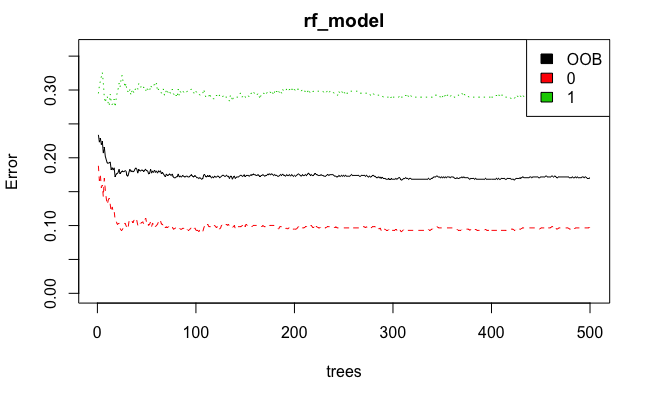

A linha preta diz que a taxa de erro foi abaixo de 20%. As linhas vermelha e verde mostram a taxa de erro para ‘morreu’ e ‘sobreviveu’, respectivamente.

## Importancia das features

Quais atributos foram determinantes para ser salvo? Familia? Titulo? Idade?

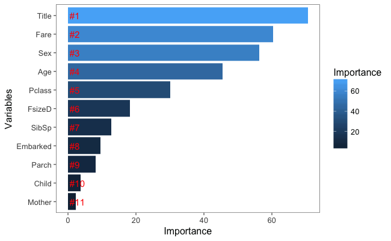

O resultado foi que o título da pessoa foi quem definiu se seria salvo ou não. A taxa de embarque é uma variável associada ao título, pois quanto maior o título, maior o valor pago na taxa de embarque. Sexo é uma boa variável, pois levou-se a sério o lema ‘mulheres e crianças primeiro’. Mas uma contra indicação à isso é a variável ‘child’ não ser muito importante. Levando em consideração que famílias com grande número de crianças não possuiam o ‘título’ e estavam em classes mais baixa, então é razoável dizer que as crianças de com famílias de alto título se salvaram (poucas) e crianças com baixo título não se salvaram (muitas).

Agora vamos prever os valores para nossa base de teste:

```r
factor(full$Sex)
```

[output not shown]

[output cut: 46 more lines]

# Gráficos

Aqui algumas tentativas de visualização dos resultados:

## Homem x Mulher x Idade

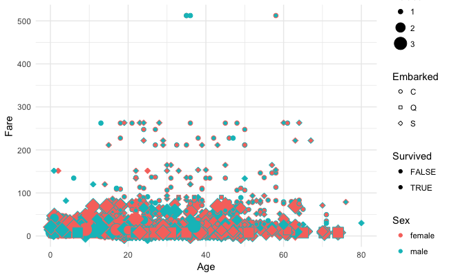

Salvar os resultados

|  | PassengerID | Survived |
| --- | --- | --- |
| 892 | 892 | 0 |
| 893 | 893 | 0 |
| 894 | 894 | 0 |
| 895 | 895 | 0 |
| 896 | 896 | 0 |
| 897 | 897 | 0 |
| 898 | 898 | 1 |
| 899 | 899 | 0 |
| 900 | 900 | 1 |
| 901 | 901 | 0 |

[output cut: 408 more lines]